# Tugas 67 MPDW

Andi Fatihatul Fuadiyah

2023-10-16

```r
library("forecast")
```

```r
library("graphics")
library("TTR")
library("TSA")
library("ggplot2")
library("tsibble")
library("tseries")
library("MASS")
```

## Data Asli

```r
library(readxl)
data <- read_excel("/Users/a.akbaryahya/Documents/PraktikumMPDW/coffee1.xlsx")
data
```

```
## # A tibble: 1,182 × 2
##    Date                Price
##    <dttm>              <dbl>
##  1 2000-01-07 00:00:00 114.
##  2 2000-01-14 00:00:00 113.
##  3 2000-01-21 00:00:00 111.
##  4 2000-01-28 00:00:00 115.
##  5 2000-02-04 00:00:00 113.
##  6 2000-02-11 00:00:00 109.
##  7 2000-02-18 00:00:00 104.
##  8 2000-02-25 00:00:00  98.8
##  9 2000-03-03 00:00:00 104.
## 10 2000-03-10 00:00:00 106.
## # ℹ 1,172 more rows
```

## Mengubah ke time series

```r
data.ts <- ts(data)
```

### Eksplorasi Data

#### Plot Data Penuh

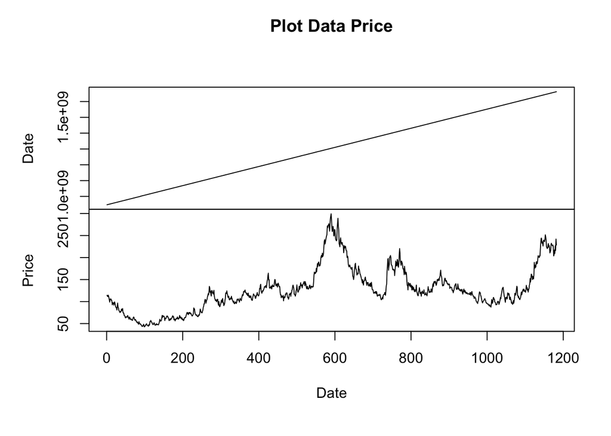

```r
plot.ts(data.ts, lty=1, xlab="Date", ylab="Price", main="Plot Data Price")
```

Berdasarkan plot data deret waktu, terlihat bahwa data cenderung fluktuatif. Berdasarkan pola data, pembagian data latih dan data uji ditetapkan dengan proporsi 80%:20%.

#### Pembagian Data

```r
training_ma <- data[1:946,]
training_ma
```

```
## # A tibble: 946 × 2
##    Date                Price
##    <dttm>              <dbl>
##  1 2000-01-07 00:00:00 114.
##  2 2000-01-14 00:00:00 113.
##  3 2000-01-21 00:00:00 111.
##  4 2000-01-28 00:00:00 115.
##  5 2000-02-04 00:00:00 113.
##  6 2000-02-11 00:00:00 109.
##  7 2000-02-18 00:00:00 104.
##  8 2000-02-25 00:00:00  98.8
##  9 2000-03-03 00:00:00 104.
## 10 2000-03-10 00:00:00 106.
## # ℹ 936 more rows
```

```r
testing_ma <- data[947:1182,]
testing_ma
```

```
## # A tibble: 236 × 2
##    Date                Price
##    <dttm>              <dbl>
##  1 2018-03-02 00:00:00  120.
##  2 2018-03-09 00:00:00  119.
##  3 2018-03-16 00:00:00  117.
##  4 2018-03-23 00:00:00  117.
##  5 2018-03-29 00:00:00  118.
##  6 2018-04-06 00:00:00  117.
##  7 2018-04-13 00:00:00  117.
##  8 2018-04-20 00:00:00  116.
##  9 2018-04-27 00:00:00  120.
## 10 2018-05-04 00:00:00  120.
## # ℹ 226 more rows
```

```r
train_ma.ts <- ts(training_ma$`Price`)
train_ma.ts
```

```
## Time Series:
## Start = 1
## End = 946
## Frequency = 1
##   [1] 114.15 112.55 111.20 114.70 112.90 108.80 104.30  98.80 104.35 106.10
##  [11] 106.10 103.15 103.70  99.60  92.65  97.75  95.30  96.85  91.80  97.95
##  [21]  99.20  95.55  91.85  87.25  87.05  84.85  80.80  89.15  96.65  87.40
##  [31]  85.60  80.65  78.40  77.75  75.00  77.40  76.25  78.00  83.00  79.45
##  [41]  81.05  84.15  75.60  73.60  74.15  68.55  68.30  67.00  63.65  62.90
##  [51]  65.40  65.55  64.35  65.00  68.30  67.10  63.20  62.65  59.80  64.95
##  [61]  63.30  61.70  59.00  60.10  60.30  58.10  57.60  57.15  60.95  63.65
##  [71]  64.95  63.80  59.90  57.90  58.15  59.40  55.90  56.10  53.85  52.05
##  [81]  53.75  51.30  50.40  48.40  54.35  50.95  50.50  48.50  49.05  48.30
##  [91]  46.65  44.70  43.85  43.40  45.40  44.70  48.65  46.40  42.60  43.00
## [101]  43.80  46.65  46.20  48.55  49.55  47.40  45.90  45.45  44.55  44.10
```

[output cut: 84 more lines]

```r
test_ma.ts <- ts(testing_ma$`Price`)
test_ma.ts
```

```
## Time Series:
## Start = 1
## End = 236
## Frequency = 1
##   [1] 120.35 118.85 116.95 117.20 118.15 117.45 117.30 115.75 120.35 120.45
##  [11] 115.25 113.95 120.40 122.75 117.25 115.20 113.85 111.50 111.25 107.05
##  [21] 110.65 110.45 107.75 107.00 101.20 100.55  98.10  98.80  95.45  99.90
##  [31] 102.45 108.95 116.55 122.10 119.65 120.05 113.85 112.60 107.15 103.25
##  [41]  98.80  96.95  99.70 100.95 101.60 103.85 104.95 106.80 103.70 102.60
##  [51]  97.95  96.45  96.95  95.30  94.60  93.90  94.50  93.20  90.40  90.20
##  [61]  92.70  89.25  89.45  87.35  93.30 104.60 100.95  96.00  99.80 108.25
##  [71] 109.45 105.20 105.85  99.75  98.15  97.30  92.85  92.60  93.60  93.85
##  [81]  99.50  98.40 100.90  99.00  93.70  95.70  99.45 104.00 109.45 106.15
##  [91] 114.60 118.55 123.70 129.45 130.70 132.50 126.35 118.95 112.15 110.15
## [101] 102.65  98.35 109.10 108.85 110.10 105.60 107.05 119.70 115.85 114.90
## [111] 118.60 116.05 105.20 104.45 110.10 104.80 103.60  96.30  98.90  95.20
## [121]  93.75  95.65 102.25  96.15 101.05 108.40 118.95 115.45 114.70 120.10
## [131] 127.10 134.80 133.35 113.60 113.65 108.95 111.55 107.25 105.60 104.40
## [141] 106.95 109.25 115.50 121.70 115.35 119.10 123.70 125.95 128.25 123.70
## [151] 128.15 124.05 122.95 124.50 121.15 127.50 136.85 128.75 132.45 125.45
## [161] 128.50 121.60 127.25 129.15 136.85 139.95 152.30 144.25 150.10 162.35
## [171] 161.65 157.45 149.90 157.25 152.55 151.30 161.20 189.00 179.55 176.00
## [181] 182.75 178.25 189.50 190.55 185.60 187.30 194.35 204.05 201.35 203.40
## [191] 199.85 203.95 203.55 219.70 233.30 243.85 244.05 232.70 235.90 231.20
## [201] 226.10 238.45 239.65 237.90 235.90 241.85 251.65 246.85 240.05 224.15
## [211] 222.95 220.30 221.85 228.40 231.65 223.60 227.30 222.55 210.45 212.90
## [221] 215.85 229.45 232.40 228.90 227.65 226.60 228.45 222.90 203.70 206.70
## [231] 217.20 209.45 226.60 215.95 242.00 228.42
```

### Plot Data Latih

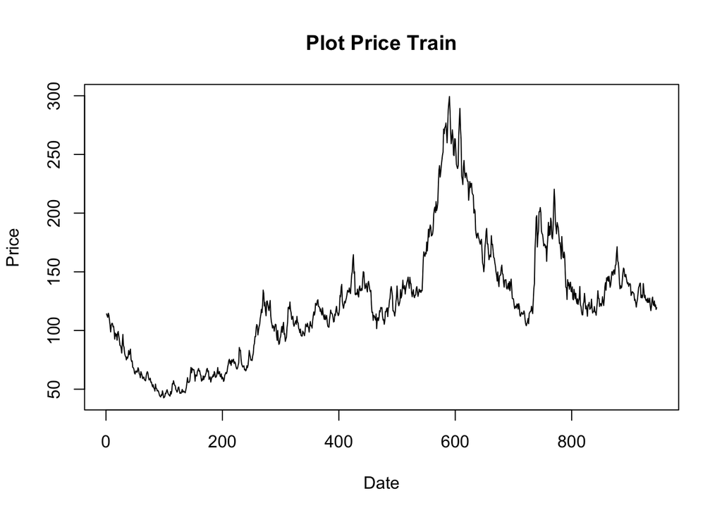

```r
train.ts<-ts(train_ma.ts)
plot.ts(train.ts, lty=1, xlab="Date", ylab="Price", main="Plot Price Train")
```

Berdasarkan plot data deret waktu pada data latih, terlihat bahwa data cenderung memiliki trend yang naik turun dan cenderung tidak bergerak pada nilai tengah tertentu. Hal ini mengindikasikan bahwa data tidak stasioner dalam rataan.

### Plot Data Uji

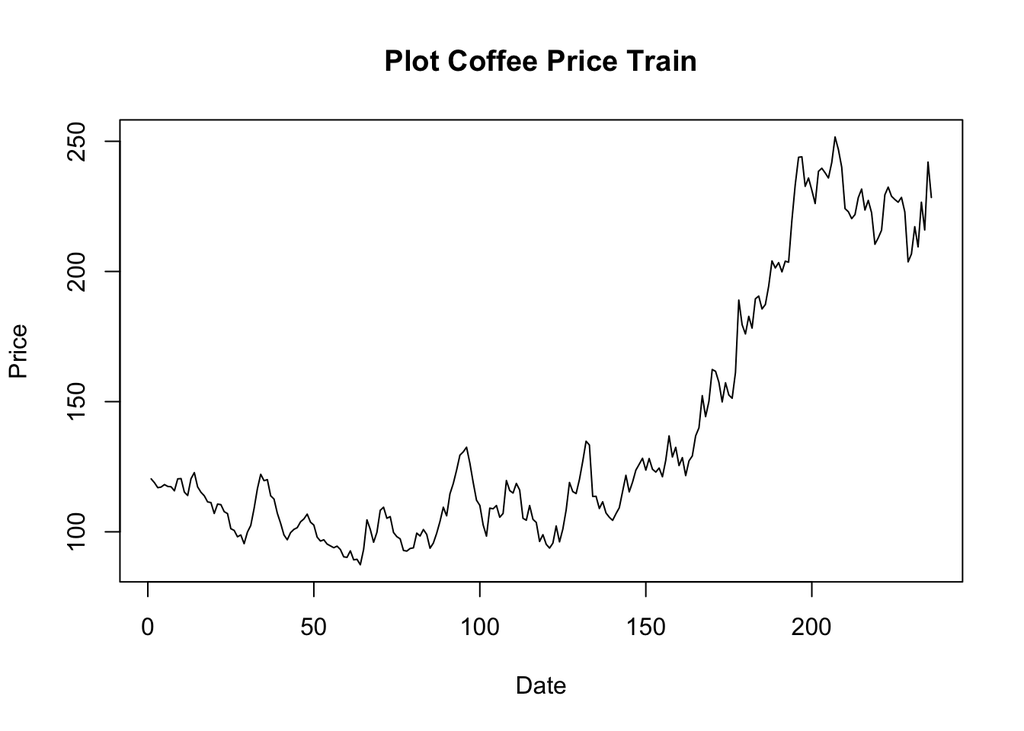

```r
test.ts<-ts(test_ma.ts)
plot.ts(test.ts, lty=1, xlab="Date", ylab="Price", main="Plot Coffee Price Train")
```

### Eksplorasi Data

Sebelum masuk dalam tahap pemodelan, dilakukan eksplorasi data dengan plot deret waktu untuk melihat pola data.

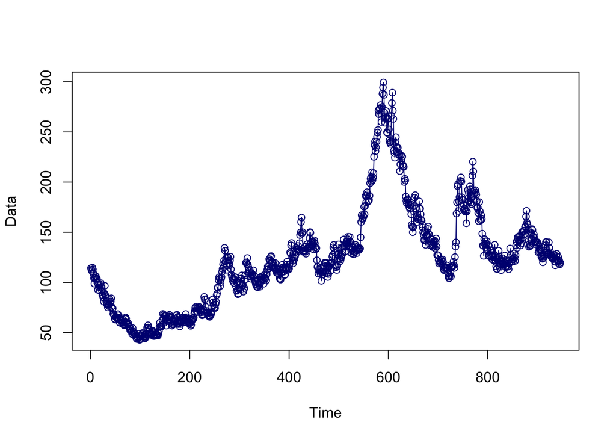

```r
#--PLOT TIME SERIES--#
plot(train_ma.ts,
     col = "navyblue",
     lwd = 1,
     type = "o",
     xlab = "Time",
     ylab = "Data")
```

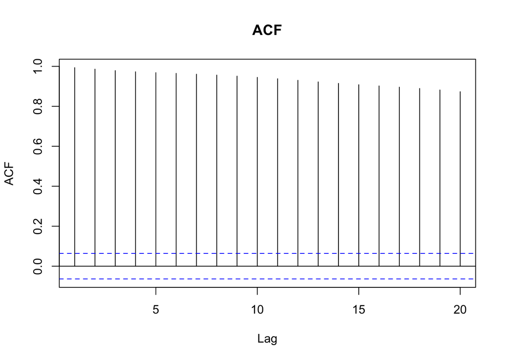

```r
#--CEK KESTASIONERAN---#
acf(train_ma.ts, main="ACF", lag.max=20)
```

Berdasarkan plot ACF, terlihat bahwa plot ACF pada data tersebut *tails off slowly* yang menandakan data tidak stasioner dalam rataan

```r
adf.test(train_ma.ts)
```

```
##
##  Augmented Dickey-Fuller Test
##
## data:  train_ma.ts
## Dickey-Fuller = -1.991, Lag order = 9, p-value = 0.5821
## alternative hypothesis: stationary
```

```r
#tidakstasioner
```

$H_0$ : Data tidak stasioner dalam rataan

$H_1$ : Data stasioner dalam rataan

Berdasarkan uji ADF tersebut, didapat *p-value* sebesar 0.5821 yang lebih besar dari taraf nyata 5% sehingga terima $H_0$ dan menandakan bahwa data tidak stasioner dalam rataan. Hal ini sesuai dengan hasil eksplorasi menggunakan plot time series dan plot ACF.

### Plot Box-Cox

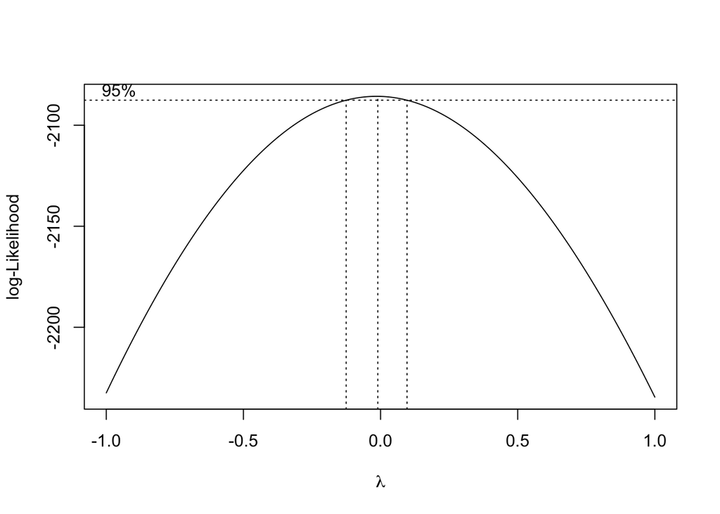

```r
index <- seq(1:946)
bc = boxcox(train_ma.ts~index, lambda = seq(-1,1,by=0.01))
```

```r
#Nilai Rounded Lambda
lambda <- bc$x[which.max(bc$y)]
lambda
```

```
## [1] -0.01
```

```r
#SK
bc$x[bc$y > max(bc$y) - 1/2 * qchisq(.95,1)]
```

```
##  [1] -0.12 -0.11 -0.10 -0.09 -0.08 -0.07 -0.06 -0.05 -0.04 -0.03 -0.02 -0.01
## [13]  0.00  0.01  0.02  0.03  0.04  0.05  0.06  0.07  0.08  0.09
```

Plot Boxcox menunjukkan nilai rounded value (λ) optimum sebesar -0.01 dan pada selang kepercayaan 95% nilai memiliki batas bawah -0.12 dan batas atas 0.09. Selang tersebut tidak memuat nilai satu sehingga dapat dikatakan bahwa data tidak stasioner dalam ragam.

### Penanganan ketidakstasioneran data

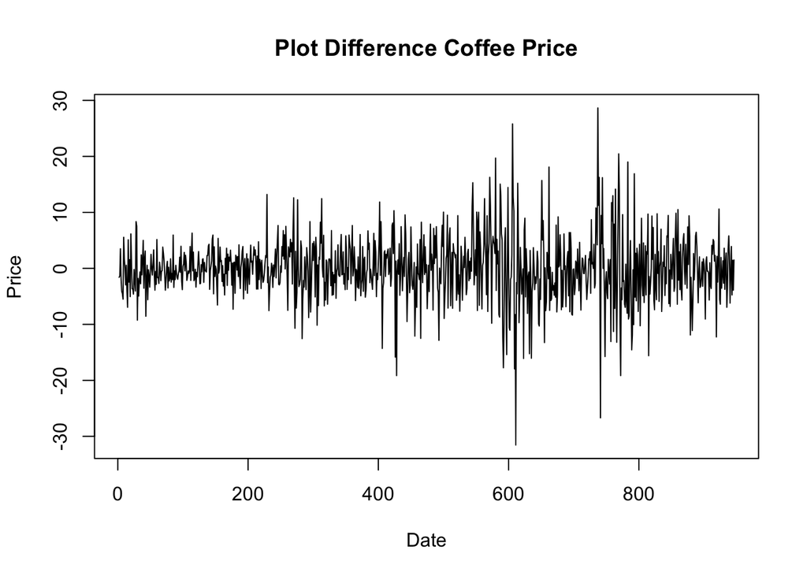

```r
train.diff<-diff(train_ma.ts,differences = 1)
plot.ts(train.diff, lty=1, xlab="Date", ylab="Price", main="Plot Difference Coffee Price")
```

#### Plot ACF

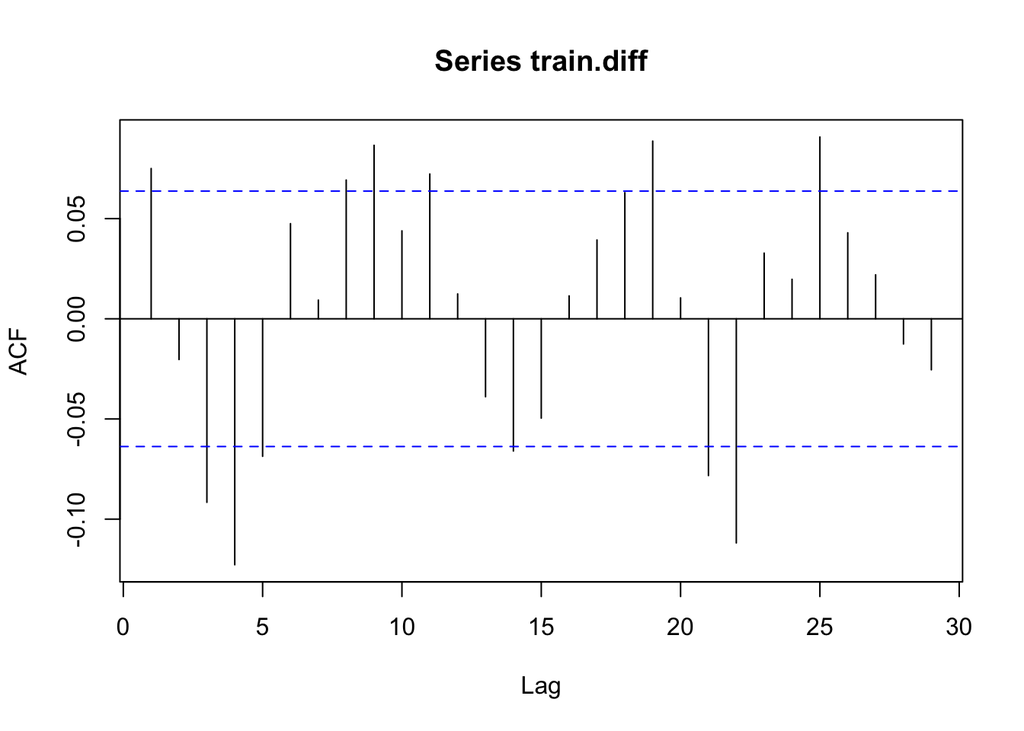

```r
acf(train.diff)
```

Berdasarkan plot tersebut, terlihat bahwa plot ACF cuts off pada lag ke 1. Hal ini menandakan data sudah stasioner dalam rataan dan ketidakstasioneran data telah berhasil tertangani.

#### Uji ADF

```r
tseries::adf.test(train.diff)
```

```
##
##  Augmented Dickey-Fuller Test
##
## data:  train.diff
## Dickey-Fuller = -8.9155, Lag order = 9, p-value = 0.01
## alternative hypothesis: stationary
```

$H_0$ : Data tidak stasioner dalam rataan

$H_1$ : Data stasioner dalam rataan

Berdasarkan uji ADF tersebut, didapat p-value sebesar 0.01 yang lebih kecil dari taraf nyata 5% sehingga tolak $H_0$ atau data stasioner dalam rataan. Hal ini sesuai dengan hasil eksplorasi menggunakan plot time series dan plot ACF, sehingga dalam hal ini ketidakstasioneran data sudah berhasil ditangani dan dapat dilanjutkan ke pemodelan

### Identifikasi Model

#### Plot ACF

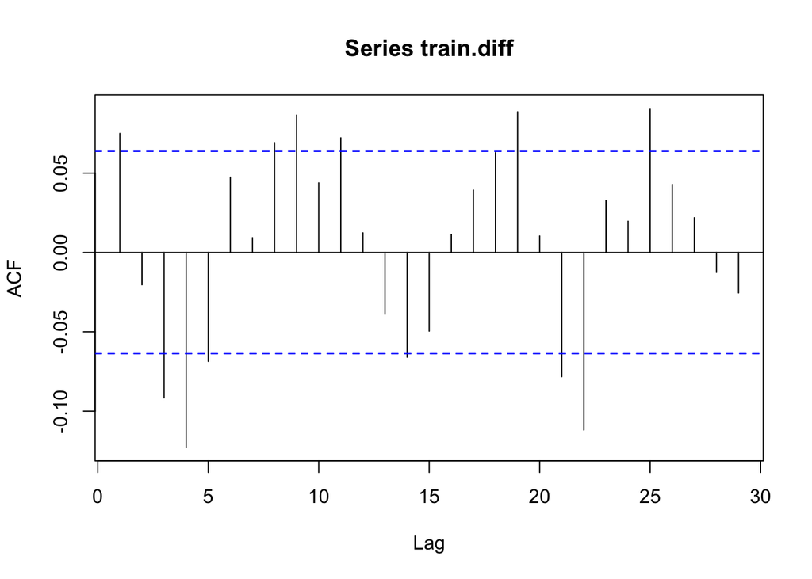

```r
acf(train.diff)
```

Berdasarkan plot tersebut, terlihat bahwa plot ACF cenderung *cuts off* pada lag ke 1, sehingga jika plot PACF dianggap *tails of*, maka model tentatifnya adalah ARIMA(0,1,1).

#### Plot PACF

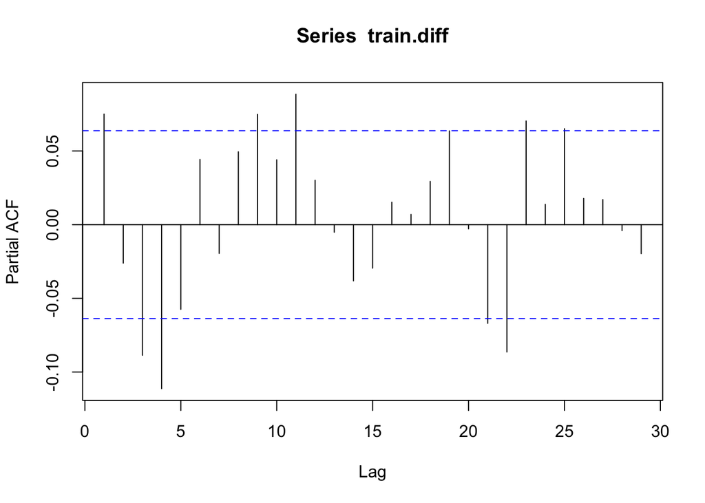

```r
pacf(train.diff)
```

Berdasarkan plot tersebut, terlihat bahwa plot PACF cenderung *cuts off* pada lag ke 1, sehingga jika plot ACF dianggap *tails of*, maka model tentatifnya adalah ARIMA(1,1,0).

Jika baik plot ACF maupun plot PACF keduanya dianggap tails of, maka model yang terbentuk adalah ARIMA(1,1,1)

#### Plot EACF

```r
eacf(train.diff)
```

```
## AR/MA
##   0 1 2 3 4 5 6 7 8 9 10 11 12 13
## 0 x o x x x o o x x o x  o  o  x
## 1 x o o o x o o o o o o  o  o  o
## 2 x x o o x o o o o o x  o  o  o
## 3 x x x o o x o o o o o  o  o  o
## 4 x x o x o x o o o o o  o  o  o
## 5 x x x x x x o o o o o  o  o  o
## 6 x x o x x x o o o o o  o  o  o
## 7 x x o x x x o o o o o  o  o  o
```

Identifikasi model menggunakan plot EACF dilakukan dengan melihat ujung segitiga pada pola segitiga nol. Dalam hal ini model tentatif yang terbentuk adalah ARIMA(0,1,1), ARIMA(1,1,2), ARIMA(2,1,2)

### Pendugaan Parameter Model Tentatif

#### ARIMA(1,1,1)

```r
model3.da=Arima(train.diff, order=c(1,1,1),method="ML")
summary(model3.da) #AIC=5980.81
```

```
## Series: train.diff
## ARIMA(1,1,1)
##
## Coefficients:
##          ar1      ma1
##       0.0756  -1.0000
## s.e.  0.0325   0.0036
##
## sigma^2 = 32.67:  log likelihood = -2987.4
## AIC=5980.81   AICc=5980.83   BIC=5995.36
##
## Training set error measures:
##                     ME     RMSE      MAE MPE MAPE      MASE        ACF1
## Training set 0.1134616 5.706544 4.132275 NaN  Inf 0.7128987 0.001133457
```

```r
lmtest::coeftest(model3.da) #seluruh parameter signifikan
```

```
##
## z test of coefficients:
##
##       Estimate Std. Error   z value Pr(>|z|)
## ar1  0.0756201  0.0324571    2.3299  0.01981 *
## ma1 -0.9999862  0.0036086 -277.1100  < 2e-16 ***
## ---
## Signif. codes:  0 '***' 0.001 '**' 0.01 '*' 0.05 '.' 0.1 ' ' 1
```

#### ARIMA(0,1,2)

```r
model4.da=Arima(train.diff, order=c(0,1,2),method="ML")
summary(model4.da) #AIC=5980.63
```

```
## Series: train.diff
## ARIMA(0,1,2)
##
## Coefficients:
##           ma1      ma2
##       -0.9218  -0.0782
## s.e.   0.0327   0.0325
##
## sigma^2 = 32.66:  log likelihood = -2987.31
## AIC=5980.63   AICc=5980.66   BIC=5995.18
##
## Training set error measures:
##                     ME     RMSE      MAE MPE MAPE      MASE         ACF1
## Training set 0.1138005 5.705942 4.131872 NaN  Inf 0.7128292 -0.001848517
```

```r
lmtest::coeftest(model4.da) #seluruh parameter signifikan
```

```
##
## z test of coefficients:
##
##      Estimate Std. Error  z value Pr(>|z|)
## ma1 -0.921844   0.032713 -28.1793  < 2e-16 ***
## ma2 -0.078156   0.032517  -2.4035  0.01624 *
## ---
## Signif. codes:  0 '***' 0.001 '**' 0.01 '*' 0.05 '.' 0.1 ' ' 1
```

#### ARIMA(1,1,2)

```r
model5.da=Arima(train.diff, order=c(1,1,2),method="ML")
summary(model5.da) #AIC=5982.61
```

```
## Series: train.diff
## ARIMA(1,1,2)
##
## Coefficients:
##          ar1      ma1      ma2
##       -0.045  -0.8774  -0.1226
## s.e.   0.273   0.2697   0.2697
##
## sigma^2 = 32.7:  log likelihood = -2987.31
## AIC=5982.61   AICc=5982.65   BIC=6002.01
##
## Training set error measures:
##                     ME     RMSE      MAE MPE MAPE      MASE         ACF1
## Training set 0.1141719 5.705867 4.131679 NaN  Inf 0.7127958 -0.001488025
```

```r
lmtest::coeftest(model5.da) #terdapat parameter tidak signifikan
```

```
##
## z test of coefficients:
##
##      Estimate Std. Error z value Pr(>|z|)
## ar1 -0.045045   0.273031 -0.1650 0.868959
## ma1 -0.877411   0.269707 -3.2532 0.001141 **
## ma2 -0.122589   0.269683 -0.4546 0.649422
## ---
## Signif. codes:  0 '***' 0.001 '**' 0.01 '*' 0.05 '.' 0.1 ' ' 1
```

#### ARIMA(2,1,2)

```r
model6.da=Arima(train.diff, order=c(2,1,2),method="ML")
summary(model6.da) #AIC=5984.81
```

```
## Series: train.diff
## ARIMA(2,1,2)
##
## Coefficients:
```

```
##          ar1     ar2      ma1      ma2
##       -0.337  0.0297  -0.5868  -0.4132
## s.e.     NaN     NaN      NaN      NaN
##
## sigma^2 = 32.74:  log likelihood = -2987.4
## AIC=5984.81   AICc=5984.87   BIC=6009.06
##
## Training set error measures:
##                    ME     RMSE      MAE MPE MAPE      MASE         ACF1
## Training set 0.113524 5.706489 4.132077 NaN  Inf 0.7128645 0.0004731728
```

```r
lmtest::coeftest(model6.da) #terdapat parameter tidak signifikan
```

```
##
## z test of coefficients:
##
##      Estimate Std. Error z value Pr(>|z|)
## ar1 -0.337048        NaN     NaN      NaN
## ar2  0.029745        NaN     NaN      NaN
## ma1 -0.586757        NaN     NaN      NaN
## ma2 -0.413243        NaN     NaN      NaN
```

Berdasarkan pendugaan parameter di atas, nilai AIC terkecil dimiliki oleh model ARIMA(0,1,2) dan parameter model ARIMA(0,1,2) juga seluruhnya signifikan sehingga model yang dipilih adalah model ARIMA(0,1,2).

### Analisis Sisaan

Model terbaik hasil identifikasi kemudian dicek asumsi sisaannya. Sisaan model ARIMA harus memenuhi asumsi normalitas, kebebasan sisaan, dan kehomogenan ragam. Diagnostik model dilakukan secara eksplorasi dan uji formal.